# Лабораторна робота № 3

**Тема.** Основи вибіркового методу

**Мета:** засвоїти основи статистичного оцінювання характеристик випадкової величини на основі вибіркового підходу засобами мови програмування R; набути навичок роботи у середовищі RStudio із застосуванням концепції «грамотного програмування» із застосуванням пакету R Markdown.

**Хід Роботи**

Генеруємо вибірку з нормального розподілу з параметрами a = 0, σ = 2 об’єму n = 200:

```r
a <- 0
s <- 2
n <- 200
n3 <- 1000
```

Генеруємо вибірку нормального розподілу

```r
set.seed(0)
X <- rnorm(n, a, s)
X3 <- rexp(n3, rate = 3)
cat("\n", "Параметри вибірки X:", "\n", "a = ", a, "\n" , "s = ", s, "\n" , "n = ", n, "\n")
```

```
##
##  Параметри вибірки X:
##  a =  0
##  s =  2
##  n =  200
```

```r
cat("Перші елементи вибірки X:", head(X))
```

```
## Перші елементи вибірки X: 2.525909 -0.6524667 2.659599 2.544859 0.8292829 -3.0799
```

```r
cat("Останні елементи вибірки X:", tail(X))
```

```
## Останні елементи вибірки X: 1.921585 3.58097 -2.12833 0.03527309 -0.7798173 -0.9816655
```

```r
cat("\n", "Параметри вибірки X3:", "\n", "a = ", a, "\n" , "s = ", s, "\n" , "n =  ", n3, "\n")
```

[output not shown]

```r
cat("Перші елементи вибірки X3:", head(X3))
```

```
## Перші елементи вибірки X3: 0.52302 0.1059184 0.6222847 0.2074471 0.1491272 0.3915251
```

```r
cat("Останні елементи вибірки X3:", tail(X3))
```

```
## Останні елементи вибірки X3: 0.7350492 0.09144798 0.4487902 0.2495899 0.1960473 0.845667
```

Вивід сумарних статистик

```r
summary(X)
```

```
##     Min.  1st Qu.   Median     Mean  3rd Qu.     Max.
## -4.44780 -1.54007 -0.21235 -0.02288  1.20758  5.31732
```

Скомпонуємо результати у компактний варіант виводу основних графіків вибіркових характеристик

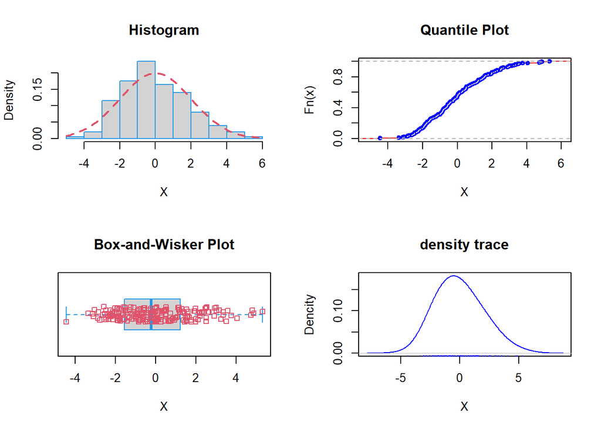

```r
op <- par(mfrow = c(2,2))
Fn <- ecdf(table(cut(X, nclass.Sturges(X))))
Fn <- ecdf(X)

hist(X,
freq = FALSE,
col = "Lightgray",
main="Histogram",
border=4)
curve(dnorm(x, a, s),
col = 2,
lty = 2,
lwd = 2,
add = TRUE)

plot(Fn,
main = "Quantile Plot",
verticals = TRUE,
col.points = "blue",
col.hor = "red",
col.vert = "bisque",
xlab = "X",
ylab = "Fn(x)")

boxplot(X,
main = "Box-and-Wisker Plot",
col = "Lightgray",
border = 4,
xlab = "X",
ylab = "",
horizontal = TRUE)

stripchart(X, method = "jitter", col = 2, add = TRUE)

plot(density(X, adjust=2),
main = "density trace",
xlab = "X",
ylab = "Dencity",
col="blue")
rug(X, ticksize = 0.01, col="blue")
```

Результати моделювання зводимо у таблицю

```r
library(knitr)
results <- data.frame(
  Характеристика = c("Математичне сподівання", "Дисперсія", "Виправлена дисперсія",
                     "СКВ", "Виправлене СКВ", "Центральний момент 3-го порядку",
                     "Центральний момент 4-го порядку", "Асимметрія", "Ексцес"),
  Теоретичне_значення = c(a, s^2, NA, s, NA, NA, NA, NA, NA),
  Вибірка_X = c(mean(X), var(X), var(X) * n / (n - 1), sd(X), sqrt(var(X) * n / (n - 1)),
                mu_3, mu_4, A_s, E_k),
  Вибірка_X3 = c(mean(X3), var(X3), var(X3) * n3 / (n3 - 1), sd(X3),
                 sqrt(var(X3) * n3 / (n3 - 1)), mu_3_X3, mu_4_X3, A_s_X3, E_k_X3)
)

kable(results, caption = "Результати обчислень")
```

Результати обчислень

| Характеристика | Теоретичне_значення | Вибірка_X | Вибірка_X3 |
| --- | --- | --- | --- |
| Математичне сподівання | 0 | -0.0228831 | 0.3498752 |
| Дисперсія | 4 | 3.4099581 | 0.1206401 |
| Виправлена дисперсія | NA | 3.4270936 | 0.1207608 |
| СКВ | 2 | 1.8466072 | 0.3473328 |
| Виправлене СКВ | NA | 1.8512411 | 0.3475066 |
| Центральний момент 3-го порядку | NA | 2.9111854 | 0.0827216 |
| Центральний момент 4-го порядку | NA | 32.4464163 | 0.1206664 |
| Асимметрія | NA | 0.4623238 | 1.9741553 |
| Ексцес | NA | -0.2095860 | 5.2909322 |

**Відповіді на контрольні питання**

1. **Що таке вибірка?**

Вибірка — це підмножина елементів з усієї популяції, яку обирають для проведення статистичних аналізів. Вибірка дозволяє зробити висновки щодо характеристик популяції, не потребуючи дослідження кожного її елемента. Вибірки можуть бути:

- **Справедливими (random)** — коли кожен елемент популяції має рівну ймовірність потрапити у вибірку.
- **Стратегіями (stratified)** — коли популяція ділиться на підгрупи (страти), і вибірка формується з кожної підгрупи окремо.
2. **Як можна оцінити вибіркове математичне сподівання?**

Вибіркове математичне сподівання або середнє значення вибірки обчислюється як середнє арифметичне всіх елементів вибірки. Для цього всі значення вибірки сумуються, а потім поділяються на кількість елементів у вибірці.

3. **Які існують міри розсіювання?**

Міри розсіювання дають змогу оцінити варіативність або відхилення даних від їхнього середнього значення. Основні міри:

- **Дисперсія ($𝜎^2$)**: вимірює середньоквадратичне відхилення кожного елементу вибірки від середнього значення.
- **Середнє квадратичне відхилення (СКВ, σ)**: це квадратний корінь з дисперсії, що вказує на середнє відхилення значень від середнього.
- **Розмах**: це різниця між найбільшим і найменшим значенням у вибірці.
4. **Які міри форми розподілу вам відомі? Що вони характеризують? Як їх оцінити на практиці?**

Міри форми розподілу дають уявлення про те, як розподілені дані в межах вибірки:

- **Асиметрія (Skewness)**: вказує на напрямок асиметрії розподілу. Якщо асиметрія більша за нуль, то розподіл має правий хвіст, якщо менша за нуль — лівий хвіст.
- **Ексцес (Kurtosis)**: визначає, наскільки розподіл є піковим або плоским порівняно з нормальним розподілом. Ексцес більше 3 вказує на пік, менше — на плаский розподіл.

Для обчислення асиметрії та ексцесу на практиці часто використовуються статистичні програми, як-от R або Python (з бібліотекою `scipy.stats` для Python, функціями `skew()` та `kurtosis()` в R).